# Accident Analysis

蔡宇媗(組別：馬路如虎口 獅子大開口)

2022-12-13

下載套件(下載一次即可) here套件可允許載入含中文名稱的資料，讀取路徑與此Rmd檔案為同一資料夾 aTSA、TSA為時間序列套件，處理發生時間用

```r
#install.packages('here')
#install.packages('aTSA')
#install.packages('TSA')
```

資料下載：都是清洗過後的資料，包含： 1. 雙方性別 2. 雙方交通工具：按照法律規定分為汽車、機慢車、行人、職業駕駛(雖已廢除，但小組想驗證是否這點已經沒有影響力) 3. 雙方經濟狀況：分為較佳(富裕及小康)、普通、較差(清寒及貧窮)三個類別 4. 請求人身分：法定上配偶、子女與父母有慰撫金的請求權 5. 正式資料：包含日期、鑑定會給予責任(分為被告責任較重、被告同等責任、被告責任較輕三個類別)、請求金額與前面經檢定為顯著且與其他變數獨立的自變數

```r
library(here)
CSV1<-here::here("gender.csv") #性別
gender<-read.csv(CSV1,header=TRUE, sep=",",fileEncoding = 'BIG5')
head(gender)
```

```
##   被告性別 原告性別 慰撫金金額
## 1        1        0      4e+06
## 2        1        1      3e+06
## 3        1        1      3e+06
## 4        1        1      2e+06
## 5        1        0      2e+06
## 6        0        0      1e+06
```

```r
CSV2<-here::here("transportation.csv") #交通工具
trans<-read.csv(CSV2,header=TRUE, sep=",",fileEncoding = 'BIG5')
head(trans)
```

```
##   被告交通工具 被告汽車 被告機慢車 被告職業駕駛 原告交通工具 原告汽車
## 1            4        0          0            1            6        0
## 2            4        0          0            1            6        0
## 3            4        0          0            1            6        0
## 4            4        0          0            1            5        0
## 5            4        0          0            1            5        0
## 6            4        0          0            1            2        0
##   原告機慢車 原告行人   慰撫金金額
## 1          0        1 4,000,000.00
## 2          0        1 3,000,000.00
## 3          0        1 3,000,000.00
## 4          1        0 2,000,000.00
## 5          1        0 2,000,000.00
## 6          1        0 1,000,000.00
```

```r
CSV3<-here::here("socialstatus.csv") #經濟狀況
socialstatus<-read.csv(CSV3,header=TRUE, sep=",",fileEncoding = 'BIG5')
head(socialstatus)
```

```
##   被告經濟狀況 被告較佳 被告中等 被告較差 原告經濟狀況 原告較佳 原告中等
## 1           99        0        0        0           99        0        0
## 2           99        0        0        0           99        0        0
## 3           99        0        0        0           99        0        0
## 4            4        0        0        1            2        1        0
## 5            4        0        0        1            2        1        0
## 6           99        0        0        0           99        0        0
##   原告較差 原被告差距 慰撫金金額
## 1        0         99    4000000
## 2        0         99    3000000
## 3        0         99    3000000
## 4        0         -2    2000000
## 5        0         -2    2000000
## 6        0         99    1000000
```

```r
CSV4<-here::here("people.csv") #請求人身分
identity<-read.csv(CSV4,header=TRUE, sep=",",fileEncoding = 'BIG5')
head(identity)
```

```
##   請求權人身分 請求權人子女 請求權人父母 請求權人人數 慰撫金金額
## 1            3            1            0            3      4e+06
## 2            3            1            0            3      3e+06
## 3            3            1            0            3      3e+06
## 4            4            0            1            3      2e+06
## 5            4            0            1            3      2e+06
## 6            2            0            0            4      1e+06
```

```r
CSV5<-here::here("date.csv") #正式資料
date<-read.csv(CSV5,header=TRUE, sep=",",fileEncoding = 'BIG5')
head(date)
```

```
##    發生日期 慰撫金金額 請求慰撫金金額 鑑定會給予被告責任 被告責任較重
## 1  2016/1/7    4000000        1500000                  2            1
## 2  2016/1/7    3000000        1500000                  2            1
## 3  2016/1/7    3000000        1500000                  2            1
## 4 2016/2/27    2000000        3988835                 99            0
## 5 2016/2/27    2000000        4015633                 99            0
## 6 2016/3/30    1000000        1500000                 99            0
##   被告責任同等 被告責任較輕 鑑定會給予原告責任 原被告差距 被告職業駕駛
## 1            0            0                  4         99            1
## 2            0            0                  4         99            1
## 3            0            0                  4         99            1
## 4            0            0                 99         -2            1
## 5            0            0                 99         -2            1
## 6            0            0                 99         99            1
##   請求權人人數
## 1            3
## 2            3
## 3            3
## 4            3
## 5            3
## 6            4
```

1. 性別的相關性檢定(不顯著) 使用線性迴歸，若coefficients的p-value小於0.05，即為顯著，該變數與判決的慰撫金有相關 金額的變數包含自變數「請求慰撫金」與應變數「最終判決慰撫金」為了讓數據分布趨於常態，因此取log10

```r
money<-log10(gender$慰撫金) #log10轉換慰撫金數值
#線性迴歸
glm1<-glm(money~gender$被告性別,family=gaussian(),data=gender)
summary(glm1)
```

```
##
## Call:
## glm(formula = money ~ gender$被告性別, family = gaussian(),
##     data = gender)
##
## Deviance Residuals:
##      Min        1Q    Median        3Q       Max
## -0.49325  -0.17341  -0.01613   0.10881   0.50675
##
## Coefficients:
##                 Estimate Std. Error t value Pr(>|t|)
## (Intercept)      6.09136    0.04830 126.109   <2e-16 ***
## gender$被告性別  0.10086    0.05147   1.959   0.0522 .
## ---
## Signif. codes:  0 '***' 0.001 '**' 0.01 '*' 0.05 '.' 0.1 ' ' 1
##
## (Dispersion parameter for gaussian family taken to be 0.05567853)
##
##     Null deviance: 7.5633  on 133  degrees of freedom
## Residual deviance: 7.3496  on 132  degrees of freedom
## AIC: -2.7531
##
## Number of Fisher Scoring iterations: 2
```

```r
glm11<-glm(money~gender$原告性別,family=gaussian(),data=gender)
summary(glm11)
```

```
##
## Call:
## glm(formula = money ~ gender$原告性別, family = gaussian(),
##     data = gender)
##
## Deviance Residuals:
##     Min       1Q   Median       3Q      Max
## -0.5239  -0.1591  -0.0181   0.1419   0.5399
##
## Coefficients:
##                 Estimate Std. Error t value Pr(>|t|)
## (Intercept)      6.19419    0.02874  215.54   <2e-16 ***
## gender$原告性別 -0.03509    0.04126   -0.85    0.397
## ---
## Signif. codes:  0 '***' 0.001 '**' 0.01 '*' 0.05 '.' 0.1 ' ' 1
##
## (Dispersion parameter for gaussian family taken to be 0.05698571)
##
##     Null deviance: 7.5633  on 133  degrees of freedom
## Residual deviance: 7.5221  on 132  degrees of freedom
## AIC: 0.35652
##
## Number of Fisher Scoring iterations: 2
```

2. 雙方交通工具相關性檢定(被告為職業駕駛時顯著)

```r
#交通工具差異
glm2<-glm(money~trans$被告職業駕駛+
               trans$被告機慢車+trans$被告汽車+trans$原告行人+
               trans$原告機慢車+trans$原告汽車,family=gaussian(),data=trans)
summary(glm2)
```

```
##
## Call:
## glm(formula = money ~ trans$被告職業駕駛 + trans$被告機慢車 +
##     trans$被告汽車 + trans$原告行人 + trans$原告機慢車 +
##     trans$原告汽車, family = gaussian(), data = trans)
##
## Deviance Residuals:
##      Min        1Q    Median        3Q       Max
## -0.55728  -0.15673  -0.03566   0.14169   0.57043
##
## Coefficients:
##                    Estimate Std. Error t value Pr(>|t|)
## (Intercept)         6.28427    0.15007  41.877   <2e-16 ***
## trans$被告職業駕駛  0.18850    0.09032   2.087   0.0389 *
## trans$被告機慢車    0.06078    0.09526   0.638   0.5246
## trans$被告汽車      0.04708    0.09000   0.523   0.6018
## trans$原告行人     -0.17892    0.12386  -1.445   0.1510
## trans$原告機慢車   -0.21651    0.12569  -1.723   0.0874 .
## trans$原告汽車      0.01117    0.18598   0.060   0.9522
## ---
## Signif. codes:  0 '***' 0.001 '**' 0.01 '*' 0.05 '.' 0.1 ' ' 1
##
## (Dispersion parameter for gaussian family taken to be 0.05378254)
##
##     Null deviance: 7.5633  on 133  degrees of freedom
## Residual deviance: 6.8304  on 127  degrees of freedom
## AIC: -2.57
##
## Number of Fisher Scoring iterations: 2
```

```r
glm3<-glm(money~
            socialstatus$被告較佳+socialstatus$被告中等
         +socialstatus$被告較差+socialstatus$原告較佳+
            socialstatus$原告中等+socialstatus$原告較差
,family=gaussian(),data=socialstatus)
summary(glm3)
```

```
##
## Call:
## glm(formula = money ~ socialstatus$被告較佳 + socialstatus$被告中等 +
##     socialstatus$被告較差 + socialstatus$原告較佳 + socialstatus$原告中等 +
##     socialstatus$原告較差, family = gaussian(), data = socialstatus)
##
## Deviance Residuals:
##      Min        1Q    Median        3Q       Max
## -0.41457  -0.11751   0.00743   0.14468   0.58543
##
## Coefficients:
##                        Estimate Std. Error t value Pr(>|t|)
## (Intercept)            6.293604   0.029491 213.406  < 2e-16 ***
## socialstatus$被告較佳 -0.445144   0.184922  -2.407  0.01751 *
## socialstatus$被告中等  0.009635   0.071757   0.134  0.89340
## socialstatus$被告較差 -0.128630   0.069860  -1.841  0.06792 .
## socialstatus$原告較佳 -0.008623   0.073252  -0.118  0.90647
## socialstatus$原告中等 -0.189700   0.070558  -2.689  0.00814 **
## socialstatus$原告較差 -0.106277   0.141510  -0.751  0.45403
## ---
## Signif. codes:  0 '***' 0.001 '**' 0.01 '*' 0.05 '.' 0.1 ' ' 1
##
## (Dispersion parameter for gaussian family taken to be 0.04397347)
##
##     Null deviance: 7.5633  on 133  degrees of freedom
## Residual deviance: 5.5846  on 127  degrees of freedom
## AIC: -29.553
##
## Number of Fisher Scoring iterations: 2
```

```r
glm31<-glm(money~socialstatus$原被告差距,family=gaussian(),data=socialstatus)
summary(glm31)
```

```
##
## Call:
## glm(formula = money ~ socialstatus$原被告差距, family = gaussian(),
##     data = socialstatus)
##
## Deviance Residuals:
##     Min       1Q   Median       3Q      Max
## -0.4368  -0.1828  -0.0246   0.1862   0.5952
##
## Coefficients:
##                          Estimate Std. Error t value Pr(>|t|)
## (Intercept)             6.1037819  0.0261149 233.728  < 2e-16 ***
## socialstatus$原被告差距 0.0016430  0.0003909   4.203 4.82e-05 ***
## ---
## Signif. codes:  0 '***' 0.001 '**' 0.01 '*' 0.05 '.' 0.1 ' ' 1
##
## (Dispersion parameter for gaussian family taken to be 0.05053527)
##
##     Null deviance: 7.5633  on 133  degrees of freedom
## Residual deviance: 6.6707  on 132  degrees of freedom
## AIC: -15.741
##
## Number of Fisher Scoring iterations: 2
```

4. 請求人身分(不論是哪種身分，皆顯著)

```r
chisq.test(identity$請求權人子女,money)
```

```
##
##  Pearson's Chi-squared test
##
## data:  identity$請求權人子女 and money
## X-squared = 35.002, df = 18, p-value = 0.009447
```

```r
chisq.test(identity$請求權人父母,money)
```

```
##
##  Pearson's Chi-squared test
##
## data:  identity$請求權人父母 and money
## X-squared = 50.444, df = 18, p-value = 6.464e-05
```

```r
glm4<-glm(money~identity$請求權人子女,family=gaussian(),data=identity)
summary(glm4)
```

```
##
## Call:
## glm(formula = money ~ identity$請求權人子女, family = gaussian(),
##     data = identity)
##
## Deviance Residuals:
##      Min        1Q    Median        3Q       Max
## -0.60114  -0.11552  -0.02747   0.18551   0.58345
##
## Coefficients:
##                       Estimate Std. Error t value Pr(>|t|)
## (Intercept)            6.27138    0.03114 201.379  < 2e-16 ***
## identity$請求權人子女 -0.15587    0.04006  -3.891 0.000157 ***
## ---
## Signif. codes:  0 '***' 0.001 '**' 0.01 '*' 0.05 '.' 0.1 ' ' 1
##
## (Dispersion parameter for gaussian family taken to be 0.05140155)
##
##     Null deviance: 7.5633  on 133  degrees of freedom
## Residual deviance: 6.7850  on 132  degrees of freedom
## AIC: -13.463
##
## Number of Fisher Scoring iterations: 2
```

```r
glm41<-glm(money~identity$請求權人父母,family=gaussian(),data=identity)
summary(glm41) #都顯著
```

```
##
## Call:
## glm(formula = money ~ identity$請求權人父母, family = gaussian(),
##     data = identity)
##
## Deviance Residuals:
##      Min        1Q    Median        3Q       Max
## -0.66105  -0.12681  -0.03027   0.17422   0.57216
##
## Coefficients:
##                       Estimate Std. Error t value Pr(>|t|)
## (Intercept)            6.12681    0.02212 276.981  < 2e-16 ***
## identity$請求權人父母  0.20449    0.04457   4.588 1.03e-05 ***
## ---
## Signif. codes:  0 '***' 0.001 '**' 0.01 '*' 0.05 '.' 0.1 ' ' 1
##
## (Dispersion parameter for gaussian family taken to be 0.04941834)
##
##     Null deviance: 7.5633  on 133  degrees of freedom
## Residual deviance: 6.5232  on 132  degrees of freedom
## AIC: -18.736
##
## Number of Fisher Scoring iterations: 2
```

```r
glm42<-glm(money~identity$請求權人人數,family=gaussian(),data=identity)
summary(glm42) #都顯著
```

```
##
## Call:
## glm(formula = money ~ identity$請求權人人數, family = gaussian(),
##     data = identity)
##
## Deviance Residuals:
##      Min        1Q    Median        3Q       Max
## -0.54985  -0.13513  -0.03921   0.17612   0.55263
##
## Coefficients:
##                       Estimate Std. Error t value Pr(>|t|)
## (Intercept)            6.44138    0.05391  119.47  < 2e-16 ***
## identity$請求權人人數 -0.07376    0.01410   -5.23 6.48e-07 ***
## ---
## Signif. codes:  0 '***' 0.001 '**' 0.01 '*' 0.05 '.' 0.1 ' ' 1
##
## (Dispersion parameter for gaussian family taken to be 0.04746381)
##
##     Null deviance: 7.5633  on 133  degrees of freedom
## Residual deviance: 6.2652  on 132  degrees of freedom
## AIC: -24.143
##
## Number of Fisher Scoring iterations: 2
```

5. 正式資料： 先使用單根檢定(Unit Root Test)確認判決金額沒有隨著事故發生時間產生變高或是變低的趨勢

再將(A)鑑定會給予責任、請求金額與前面經檢定為顯著(與判決金額相關)且與其他變數獨立的自變數加入線性迴歸模型 (B)移除請求金額，加入職業駕駛成為另一個線性迴歸模型

考量到變數間因果關係難以釐清，且已盡量使變數間為獨立(互不影響)，所以不加入交互作用項(交互作用項：例如責任*職業駕駛兩個以上變數乘積的變項)

```r
library(aTSA)
library(TSA)
money<-log10(date$慰撫金金額)
adf.test(money) #通過-沒有時間效應
```

```
## Augmented Dickey-Fuller Test
## alternative: stationary
##
## Type 1: no drift no trend
##      lag    ADF p.value
## [1,]   0 -0.324   0.550
## [2,]   1 -0.265   0.567
## [3,]   2 -0.257   0.570
## [4,]   3 -0.172   0.594
## [5,]   4 -0.153   0.599
## Type 2: with drift no trend
##      lag   ADF p.value
## [1,]   0 -5.76    0.01
## [2,]   1 -6.06    0.01
## [3,]   2 -5.58    0.01
## [4,]   3 -4.76    0.01
## [5,]   4 -4.34    0.01
## Type 3: with drift and trend
##      lag   ADF p.value
## [1,]   0 -5.93    0.01
## [2,]   1 -6.28    0.01
## [3,]   2 -5.89    0.01
## [4,]   3 -5.09    0.01
## [5,]   4 -4.74    0.01
## ----
## Note: in fact, p.value = 0.01 means p.value <= 0.01
```

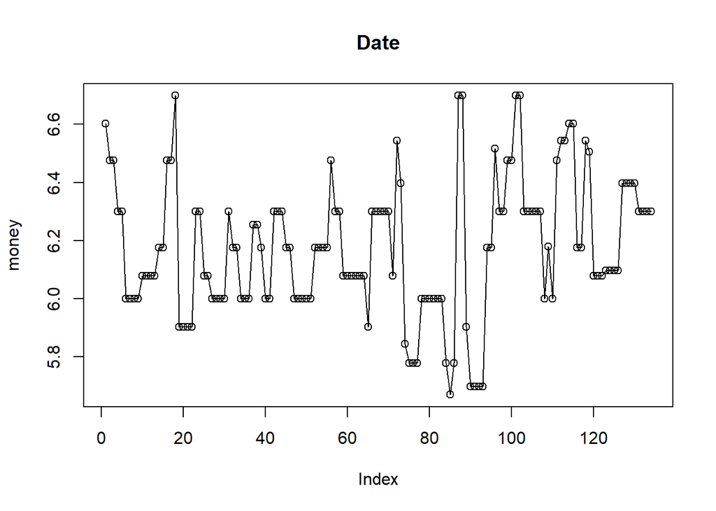

```r
#畫圖
plot(money,type="o")
title("Date")
```

```r
#線性迴歸一
askmoney<-log10(date$請求慰撫金金額)
linearglm<-glm(money~date$被告責任較重+date$被告責任同等+date$被告責任較輕
               +askmoney+date$原被告差距,family=gaussian(),data=date)
summary(linearglm)
```

```
##
## Call:
## glm(formula = money ~ date$被告責任較重 + date$被告責任同等 +
##     date$被告責任較輕 + askmoney + date$原被告差距,
##     family = gaussian(), data = date)
##
## Deviance Residuals:
##      Min        1Q    Median        3Q       Max
## -0.42210  -0.09930  -0.00029   0.11264   0.32435
##
## Coefficients:
##                    Estimate Std. Error t value Pr(>|t|)
## (Intercept)       2.2721710  0.3512320   6.469 1.90e-09 ***
## date$被告責任較重 0.1929733  0.0354569   5.442 2.58e-07 ***
## date$被告責任同等 0.2655944  0.0377119   7.043 1.03e-10 ***
## date$被告責任較輕 0.1914393  0.0396593   4.827 3.88e-06 ***
## askmoney          0.6025011  0.0567473  10.617  < 2e-16 ***
## date$原被告差距   0.0015223  0.0002859   5.324 4.41e-07 ***
## ---
## Signif. codes:  0 '***' 0.001 '**' 0.01 '*' 0.05 '.' 0.1 ' ' 1
##
## (Dispersion parameter for gaussian family taken to be 0.02284803)
##
##     Null deviance: 7.5633  on 133  degrees of freedom
## Residual deviance: 2.9245  on 128  degrees of freedom
## AIC: -118.23
##
## Number of Fisher Scoring iterations: 2
```

```r
#線性迴歸二
linearglm2<-glm(money~date$被告責任較重+date$被告責任同等+date$被告責任較輕
                +date$原被告差距+date$被告職業駕駛+date$請求權人人數,
               family=gaussian(),data=date)
summary(linearglm2)
```

```
##
## Call:
## glm(formula = money ~ date$被告責任較重 + date$被告責任同等 +
##     date$被告責任較輕 + date$原被告差距 + date$被告職業駕駛 +
##     date$請求權人人數, family = gaussian(), data = date)
##
## Deviance Residuals:
##      Min        1Q    Median        3Q       Max
## -0.50082  -0.12930   0.01022   0.12773   0.38579
##
## Coefficients:
##                     Estimate Std. Error t value Pr(>|t|)
## (Intercept)        6.2341805  0.0549271 113.499  < 2e-16 ***
## date$被告責任較重  0.1475703  0.0426613   3.459 0.000738 ***
## date$被告責任同等  0.2517851  0.0449242   5.605 1.24e-07 ***
## date$被告責任較輕  0.2326670  0.0475138   4.897 2.90e-06 ***
## date$原被告差距    0.0006811  0.0003468   1.964 0.051702 .
## date$被告職業駕駛  0.1099434  0.0350097   3.140 0.002099 **
## date$請求權人人數 -0.0706817  0.0121809  -5.803 4.91e-08 ***
## ---
## Signif. codes:  0 '***' 0.001 '**' 0.01 '*' 0.05 '.' 0.1 ' ' 1
##
## (Dispersion parameter for gaussian family taken to be 0.03249635)
##
##     Null deviance: 7.5633  on 133  degrees of freedom
## Residual deviance: 4.1270  on 127  degrees of freedom
## AIC: -70.082
##
## Number of Fisher Scoring iterations: 2
```

```r
linearglm3<-glm(money~date$被告責任較重+date$被告責任同等+date$被告責任較輕+identity$請求權人父母+
               identity$請求權人子女+date$原被告差距+date$被告職業駕駛,
               family=gaussian(),data=date)
summary(linearglm3)
```

```
##
## Call:
## glm(formula = money ~ date$被告責任較重 + date$被告責任同等 +
##     date$被告責任較輕 + identity$請求權人父母 + identity$請求權人子女 +
##     date$原被告差距 + date$被告職業駕駛, family = gaussian(),
##     data = date)
##
## Deviance Residuals:
##      Min        1Q    Median        3Q       Max
## -0.60238  -0.12563   0.03401   0.12866   0.54046
##
## Coefficients:
##                         Estimate Std. Error t value Pr(>|t|)
## (Intercept)            5.9963824  0.0472920 126.795  < 2e-16 ***
## date$被告責任較重      0.1573875  0.0433725   3.629 0.000412 ***
## date$被告責任同等      0.2323130  0.0458546   5.066 1.41e-06 ***
## date$被告責任較輕      0.2213897  0.0483360   4.580 1.10e-05 ***
## identity$請求權人父母  0.1170045  0.0527776   2.217 0.028421 *
## identity$請求權人子女 -0.0866805  0.0463988  -1.868 0.064062 .
## date$原被告差距        0.0009234  0.0003523   2.621 0.009849 **
## date$被告職業駕駛      0.1107666  0.0357736   3.096 0.002415 **
## ---
## Signif. codes:  0 '***' 0.001 '**' 0.01 '*' 0.05 '.' 0.1 ' ' 1
##
## (Dispersion parameter for gaussian family taken to be 0.03381038)
##
##     Null deviance: 7.5633  on 133  degrees of freedom
## Residual deviance: 4.2601  on 126  degrees of freedom
## AIC: -63.83
##
## Number of Fisher Scoring iterations: 2
```

補充：身分、職業駕駛與請求金額有高度相關(卡方檢定p-value < 0.05)，故這兩個變數不與請求金額出現在同一個模型

```r
chisq.test(identity$請求權人父母,askmoney) #身分與請求金額有高度相關
```

```
##
##  Pearson's Chi-squared test
##
## data:  identity$請求權人父母 and askmoney
## X-squared = 49.67, df = 19, p-value = 0.0001465
```

```r
chisq.test(askmoney,date$被告職業駕駛) #職業駕駛與請求金額有高度相關
```

```
##
##  Pearson's Chi-squared test
##
## data:  askmoney and date$被告職業駕駛
## X-squared = 60.519, df = 19, p-value = 3.202e-06
```

```r
chisq.test(askmoney,date$請求權人人數)
```

```
##
##  Pearson's Chi-squared test
##
## data:  askmoney and date$請求權人人數
## X-squared = 249.72, df = 95, p-value = 7.619e-16
```

```r
chisq.test(identity$請求權人子女,date$請求權人人數) #請求權人身分與人數有相關
```

```
##
##  Pearson's Chi-squared test
##
## data:  identity$請求權人子女 and date$請求權人人數
## X-squared = 27.271, df = 5, p-value = 5.051e-05
```

```r
chisq.test(identity$請求權人父母,date$請求權人人數)
```

```
##
##  Pearson's Chi-squared test
##
## data:  identity$請求權人父母 and date$請求權人人數
## X-squared = 30.846, df = 5, p-value = 1.005e-05
```